# Gastric cancer: exploratory analysis

**CCDL 2018**

In this notebook, we’ll import the gastric cancer data and do some exploratory analyses and visual inspection. We’ll use the [`DESeq2`](https://bioconductor.org/packages/release/bioc/html/DESeq2.html) package for this.

`DESeq2` also has an [excellent vignette](https://bioconductor.org/packages/release/bioc/vignettes/DESeq2/inst/doc/DESeq2.html) from Love, Anders, and Huber from which this is adapted (see also: [Love, Anders, and Huber. *Genome Biology*. 2014.](https://doi.org/10.1186/s13059-014-0550-8)).

## Libraries and functions

```r
library(DESeq2)
```

```r
# magrittr pipe
`%>%` <- dplyr::`%>%`
```

## Directories and files

```r
# directory with the tximport processed data
txi_dir <- file.path("data", "tximport", "gastric_cancer")
txi_file <- file.path(txi_dir, "gastric_cancer_tximport.RDS")
```

We’ll create a directory to hold our plots.

```r
plots_dir <- "plots"
if (!dir.exists(plots_dir)) {
  dir.create(plots_dir, recursive = TRUE)
}
```

```r
# sample metadata file
meta_dir <- file.path("data", "sample_metadata")
meta_file <- file.path(meta_dir, "gastric_cancer",
                       "gastric_cancer_sample_metadata.tsv")
```

**Output**

```r
# PCA plot
pca_plot_file <- file.path(plots_dir, "gastric_cancer_PC_scatter.pdf")
```

## DESeq2

### Creating a DESeq2 dataset from tximport object

First, let’s read in the data we processed with `tximport`.

```r
txi <- readr::read_rds(txi_file)
```

```r
head(txi$counts)  # gene-level counts
```

```
                SRR585570 SRR585571 SRR585572 SRR585573 SRR585574
ENSG00000000003   546.561   273.763   334.226   871.442   720.036
ENSG00000000005     1.000     0.000     0.000     0.000     0.000
ENSG00000000419   288.000   145.000  1360.001  1053.000  1047.000
ENSG00000000457   256.443   128.405   350.978   384.454   339.235
ENSG00000000460    58.797    47.997    66.536   122.284   293.917
ENSG00000000938    58.001    80.999     2.000     0.000     1.000
                SRR585575 SRR585576 SRR585577
ENSG00000000003   527.036   376.958   760.740
ENSG00000000005     0.000     0.000     0.000
ENSG00000000419  1216.001   524.001   525.000
ENSG00000000457   290.365   253.114   223.695
ENSG00000000460   752.270   169.838   303.824
ENSG00000000938     0.000     0.000     0.000
```

```r
head(txi$abundance)  # gene-level TPM
```

```
                SRR585570 SRR585571  SRR585572 SRR585573 SRR585574
ENSG00000000003 25.764967 18.747422  12.220876 25.016184 20.885660
ENSG00000000005  0.060945  0.000000   0.000000  0.000000  0.000000
ENSG00000000419 28.565247 21.443019 100.540036 64.606604 62.327711
ENSG00000000457  5.687166  3.096619   6.166913  5.055557  4.638087
ENSG00000000460  1.662361  2.756872   1.391765  2.059745  5.633326
ENSG00000000938  1.660330  3.022260   0.068182  0.000000  0.023639
                SRR585575 SRR585576 SRR585577
ENSG00000000003 16.362802 16.213927 27.060679
ENSG00000000005  0.000000  0.000000  0.000000
ENSG00000000419 74.077916 43.120019 35.343366
ENSG00000000457  3.831576  4.311724  3.472487
ENSG00000000460 15.271021  4.935273  7.710060
ENSG00000000938  0.000000  0.000000  0.000000
```

And now we’ll read in the sample metadata.

```r
sample_meta_df <- readr::read_tsv(meta_file)
sample_meta_df
```

| tissue | accession | title |
| --- | --- | --- |
| gastric_cancer_cell_line | SRR585577 | SNU668 |
| gastric_cancer_cell_line | SRR585576 | SNU601 |
| gastric_cancer_cell_line | SRR585575 | SNU484 |
| primary_gastric_tumor | SRR585574 | Primary gastric tumor-3 (40703) |
| primary_gastric_tumor | SRR585573 | Primary gastric tumor-2 (38627) |
| primary_gastric_tumor | SRR585572 | Primary gastric tumor-1 (36291) |
| gastric_normal | SRR585571 | Gastric normal (CGC-457) |
| gastric_normal | SRR585570 | Gastric normal (CGC-140) |

```r
colnames(txi$counts)
```

```
[1] "SRR585570" "SRR585571" "SRR585572" "SRR585573" "SRR585574"
[6] "SRR585575" "SRR585576" "SRR585577"
```

We’ll reorder the sample metadata to match the order in `txi`

```r
sample_meta_df <- sample_meta_df %>%
  dplyr::arrange(accession)
sample_meta_df
```

| tissue | accession | title |
| --- | --- | --- |
| gastric_normal | SRR585570 | Gastric normal (CGC-140) |
| gastric_normal | SRR585571 | Gastric normal (CGC-457) |
| primary_gastric_tumor | SRR585572 | Primary gastric tumor-1 (36291) |
| primary_gastric_tumor | SRR585573 | Primary gastric tumor-2 (38627) |
| primary_gastric_tumor | SRR585574 | Primary gastric tumor-3 (40703) |
| gastric_cancer_cell_line | SRR585575 | SNU484 |
| gastric_cancer_cell_line | SRR585576 | SNU601 |
| gastric_cancer_cell_line | SRR585577 | SNU668 |

```r
all.equal(colnames(txi$counts), sample_meta_df$accession)
```

```
[1] TRUE
```

We use the tissue of origin in the design formula because that will allow us to model this variable of interest.

```r
ddset <- DESeqDataSetFromTximport(txi = txi,
                                  colData = sample_meta_df,
                                  design = ~ tissue)
```

```
some variables in design formula are characters, converting to factorsusing counts and average transcript lengths from tximport
```

### Variance-stablizing transformation

Before visualizing the data, we’ll transform it such that it is on a `log2` scale and library size is taken into account with the `DESeq2` function for variance-stablizing transformations.

```r
vst_data <- vst(ddset)
```

```
using 'avgTxLength' from assays(dds), correcting for library size
```

### Principal components analysis

Principal components analysis (PCA) is a dimensionality reduction technique that captures the main sources of variation in our data in the first two principal components (PC1 and PC2). Visualizing PC1 and PC2 can give us insight into how different variables (e.g., tissue source) affect our dataset and help us spot any technical effects (more on that below).

`DESeq2` has built-in functionality for performing PCA.

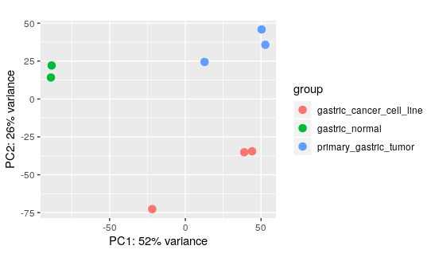

```r
DESeq2::plotPCA(vst_data, intgroup = "tissue")
```

Save the most recent plot to file with `ggsave` from `ggplot2`

```r
ggplot2::ggsave(pca_plot_file, plot = ggplot2::last_plot())
```

## A note on technical effects

We don’t have batch information (i.e., when the samples were run) for this particular experiment, but let’s imagine that `SRR585574` and `SRR585576` were run separately from all other samples. We’ll put this in new “toy” column in `sample_meta_df`.

```r
sample_meta_df$batch <- c("batch1", "batch1", "batch1", "batch1", "batch2",
                          "batch1", "batch2", "batch1")
```

Let’s rerun the `DESeq2` steps.

```r
# Note: if we were using this for differential expression AND we truly knew
# the batch, we'd likely use design = ~ batch + tissue
ddset_batch <- DESeqDataSetFromTximport(txi = txi,
                                        colData = sample_meta_df,
                                        design = ~ tissue)
```

```
some variables in design formula are characters, converting to factorsusing counts and average transcript lengths from tximport
```

```r
vst_batch <- vst(ddset_batch)
```

```
using 'avgTxLength' from assays(dds), correcting for library size
```

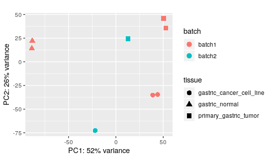

```r
pca_data <- DESeq2::plotPCA(vst_batch, intgroup = c("tissue", "batch"),
                            returnData = TRUE)
percent_var <- round(100 * attr(pca_data, "percentVar"))
ggplot2::ggplot(pca_data, ggplot2::aes(PC1, PC2, color = batch,
                                       shape = tissue)) +
  ggplot2::geom_point(size = 3) +
  ggplot2::xlab(paste0("PC1: ", percent_var[1],"% variance")) +
  ggplot2::ylab(paste0("PC2: ", percent_var[2],"% variance")) +
  ggplot2::coord_fixed()
```